# Key Stage 4, 2025/26: Provisional Results

An addendum to *How to Pull the Right Lever*. Every figure here is provisional — none of it can be confirmed until the revised data lands in February 2027.

Author

Affiliation

Adam Dennett

Bartlett Centre for Advanced Spatial Analysis, University College London

Published

October 23, 2026

**ImportantProvisional. Confirmable in February 2027.**

The 2025/26 Key Stage 4 figures are **provisional**, published by the Department for Education on 15 October 2026 and based on results before schools’ amendment requests have been applied. The **revised figures follow in February 2027**, and that is the point at which anything here can be confirmed.

That matters more than usual for this particular year. The most noticeable finding below rests on a single school’s single cohort moving a long way out of line — and a single year that far out of line is exactly the case where a revision bites hardest. **Nothing here should be treated as settled until February.**

**NoteAn addendum, not a revision**

This is a **standalone addendum** to *How to Pull the Right Lever*. That report is unchanged and still stands on its own four years of data: nothing here has been folded back into it, and every figure it publishes still reproduces from `data/panel_data.rds` exactly as before. The five-year panel this note uses is written separately, to `data/panel_data_5yr.rds`.

# 1 What arrived, and why the pipeline had to change

The 2025/26 release brings a fifth year of Key Stage 4 results. It also brings the end of the route this project used to get them.

> “Compare school and college performance (CSCP) will close soon. From autumn 2026, you will be able to use a new service. Data on CSCP will not be updated past the 2024/25 academic year.”

`R/00_download_cscp.R` can therefore fetch 2021/22 to 2024/25 and nothing after it. It is kept exactly as it is, because every published figure for those four years reproduces from the files it fetched. From 2025/26 the data comes instead from Explore Education Statistics, through `R/00b_download_ees_api.R`, and is shaped into a panel year by `R/01b_extract_ees_2526.R`.

Three things are genuinely absent from the new year, and all three are carried as explicit gaps rather than quietly filled:

| Missing | Why | Consequence |
| --- | --- | --- |
| **Progress 8** | The 2025/26 cohort has no Key Stage 2 baseline — the 2019/20 and 2020/21 primary assessments were cancelled, and DfE confirmed no replacement measure | Already true of 2024/25; the reduced “core” specification was built for exactly this |
| **Prior attainment** | Same cause | `PTPRIORLO` / `PTPRIORHI` are `NA`, as in 2024/25 |
| **Full-year absence** | 2025/26 full-year absence publishes around March 2027 | Handled below — and it is the one that mattered |

# 2 Is the new source the same as the old one?

The EES institution-level file covers 2023/24 to 2025/26, so it overlaps the panel by two years. If the mapping from the EES long format onto the panel’s column names is right, the overlap should agree.

EES institution-level data against the CSCP performance tables, on the years both cover

| Year | Measure | Schools | r | Mean difference | Agree exactly |
| --- | --- | --- | --- | --- | --- |
| 2023-2024 | Attainment 8 | 4060 | 0.9998 | 0.022 | 89% |
| 2023-2024 | Disadvantaged | 3236 | 0.9999 | 0.011 | 91% |
| 2023-2024 | Not disadvantaged | 3236 | 1.0000 | 0.014 | 88% |
| 2023-2024 | Disadvantaged share | 3280 | 1.0000 | 0.011 | 97% |
| 2024-2025 | Attainment 8 | 4061 | 0.9999 | 0.116 | 31% |
| 2024-2025 | Disadvantaged | 3250 | 0.9999 | 0.075 | 49% |
| 2024-2025 | Not disadvantaged | 3250 | 0.9998 | 0.120 | 27% |
| 2024-2025 | Disadvantaged share | 3288 | 1.0000 | 0.007 | 98% |

It does: correlations of 0.9998 to 1.0000 on every measure. The mapping is sound.

The second row group is the more interesting one. For 2023/24 the two sources agree exactly for about nine schools in ten; for 2024/25 only about three in ten, with the EES figures running a shade higher. That is not an error — it is the **provisional-to-revised revision**. The panel’s 2024/25 came from `england_ks4provisional.csv`; the EES file now carries the revised figures, which include late results and the amendments schools requested. The same thing will happen to the 2025/26 numbers in February 2027.

# 3 The absence problem, and what to do about it

Absence is the strongest single predictor in the Lever model, and the centre of its argument. Full-year absence for 2025/26 does not exist yet.

What does exist is a school-level file running **2016/17 to 2025/26** covering the **autumn and spring terms** — every year of the panel, on one consistent basis, reaching the new year. Summer term absence is excluded, so it is a different quantity from `PERCTOT` and is carried as a separate variable, `PERCTOT_2term`, never joined onto the old one.

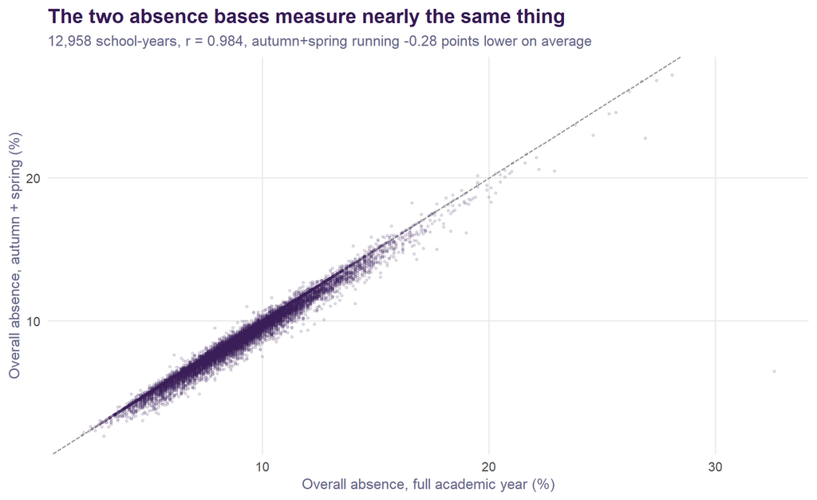

Full-year and autumn+spring absence, for the school-years where both are published

They are close: r = 0.984 across 12,958 school-years, with the two-term figure 0.28 percentage points lower on average — summer term absence is the higher part of the year, so dropping it pulls the number down slightly and almost uniformly.

**TipA note on exclusions**

The same file carries one more thing: `sess_auth_excluded`, the sessions missed because a pupil was suspended. That makes it possible to answer, from published data, a question Brighton & Hove’s council has started asking — **how much of the attendance problem is exclusion?**

The short answer is 3.1% of it nationally, against 46% for illness — and less than that in Brighton & Hove, which suspends below the English average while attending worse than all but two local authorities.

**Exclusions and Attendance →**

# 4 Does the conclusion survive?

The question worth asking is not “can a fifth year be added” but “does adding it change the answer”. Three fits separate the two things that could move the result — the change of absence basis, and the extra year.

The core specification, fitted three ways

| Fit | Years | Absence | School-years | Absence coefficient | Disadvantage coefficient |
| --- | --- | --- | --- | --- | --- |
| A. Published baseline | 2021/22–2024/25 | Full year | 12,857 | -0.2616 | -0.1281 |
| B. Absence basis swapped | 2021/22–2024/25 | Autumn + spring | 12,857 | -0.2613 | -0.1283 |
| C. Fifth year added | 2021/22–2025/26 | Autumn + spring | 15,745 | -0.2646 | -0.1260 |

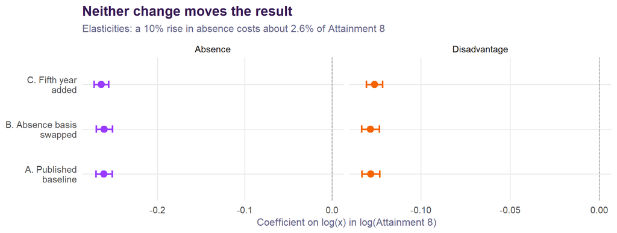

Absence and disadvantage coefficients across the three fits, with 95% intervals

The absence elasticity goes **-0.2616 → -0.2613 → -0.2646**. The disadvantage elasticity goes **-0.1281 → -0.1283 → -0.1260**.

Every one of those moves is far inside the standard errors. Swapping the absence basis is close to free, and a fifth year of data leaves the central finding exactly where it was: **absence carries roughly twice the weight of disadvantage**, and it is the variable policy has most purchase on.

That is the most useful thing a new year of data can do. It was a chance for the conclusion to fail, and it did not.

# 5 What actually changed in 2025/26

Across 3,982 matched state-funded mainstream schools in England, headline Attainment 8 was **flat**: a change of -0.11 points. Underneath it, something more interesting:

- disadvantaged pupils **+0.68**, from 37.8 to 38.4
- everyone else **+0.36**, from 50.0 to 50.3
- the **disadvantage gap narrowed by 0.31 points**, from 12.21 to 11.90

A flat headline hiding a narrowing gap is precisely the pattern a measure built on averages is bad at showing, and precisely the one that matters.

## 5.1 Brighton and Hove

Brighton and Hove state-funded secondary schools, 2024/25 to 2025/26 (provisional)

| School | A8 2024/25 | A8 2025/26 | Change | Disadvantaged 2024/25 | Disadvantaged 2025/26 | Disadvantaged change | Disadvantaged % |
| --- | --- | --- | --- | --- | --- | --- | --- |
| Varndean | 48.8 | 54.7 | 5.9 | 33.8 | 37.7 | 3.9 | 21.2 |
| Longhill | 32.9 | 36.3 | 3.4 | 25.5 | 30.4 | 4.9 | 33.5 |
| King’s | 53.7 | 56.5 | 2.8 | 35.3 | 46.4 | 11.1 | 19.9 |
| Blatchington Mill | 51.0 | 52.5 | 1.5 | 38.4 | 42.4 | 4.0 | 21.3 |
| Portslade Aldridge | 42.7 | 44.1 | 1.4 | 31.1 | 35.9 | 4.8 | 37.7 |
| Patcham | 45.5 | 46.7 | 1.2 | 33.5 | 33.2 | -0.3 | 25.9 |
| Hove Park School | 41.1 | 42.0 | 0.9 | 32.4 | 30.8 | -1.6 | 36.1 |
| Cardinal Newman Catholic | 50.4 | 50.9 | 0.5 | 40.2 | 39.2 | -1.0 | 21.8 |
| Dorothy Stringer | 53.3 | 50.5 | -2.8 | 36.2 | 34.6 | -1.6 | 22.3 |
| BACA | 36.2 | 33.2 | -3.0 | 33.3 | 21.9 | -11.4 | 45.6 |

The city moved **+1.18 points** against a national change of -0.11. Two movements stand out, and they are in opposite directions: Longhill High School, and Brighton Aldridge Community Academy — **BACA** from here on.

**Note**

Both of those movements are smaller than they look here. Attainment 8 is a mean over every pupil on roll, entered or not, and the entry rates at these two schools moved sharply in opposite directions. §7 measures the same years on the pupils who were actually entered; read it before quoting either figure.

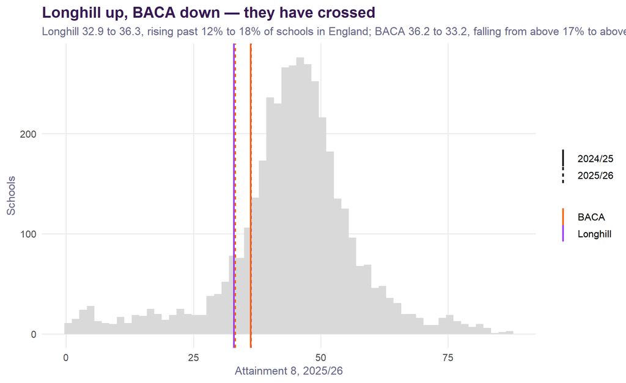

Longhill and BACA, against the national distribution of Attainment 8

**Longhill rose +3.4 points** and its disadvantaged pupils rose +4.9. **BACA fell -3.0**, with its disadvantaged pupils falling -11.4. On the headline measure the two schools have swapped places.

## 5.2 Did BACA simply take a harder intake?

That is the first thing to rule out, and the answer is no — the composition moved the other way.

Cohort composition and scores, three years

| School | Year | Cohort | Disadvantaged % | A8 all | A8 disadvantaged | A8 not disadvantaged | Internal gap |
| --- | --- | --- | --- | --- | --- | --- | --- |
| BACA | 2023/24 | 117 | 47.0 | 37.3 | 32.9 | 41.1 | 8.2 |
| BACA | 2024/25 | 116 | 52.6 | 36.2 | 33.3 | 39.5 | 6.2 |
| BACA | 2025/26 | 147 | 45.6 | 33.2 | 21.9 | 42.7 | 20.8 |
| Longhill | 2023/24 | 169 | 31.4 | 36.1 | 29.1 | 39.3 | 10.2 |
| Longhill | 2024/25 | 162 | 40.1 | 32.9 | 25.5 | 37.9 | 12.4 |
| Longhill | 2025/26 | 158 | 33.5 | 36.3 | 30.4 | 39.3 | 8.9 |

BACA’s cohort **grew**, from 116 to 147, and its disadvantaged share **fell**, from 52.6% to 45.6%. A smaller disadvantaged share should push the headline score *up*. Its non-disadvantaged pupils also did better, 39.5 to 42.7.

The headline fell anyway, because the disadvantaged half of the school fell 11.4 points. **The gap between the two groups inside the school went from 6.2 points to 20.8** in a single year.

Longhill moved in the opposite direction on every line: disadvantaged share down from 40.1% to 33.5%, both groups up, and its internal gap narrowing from 12.4 to 8.9.

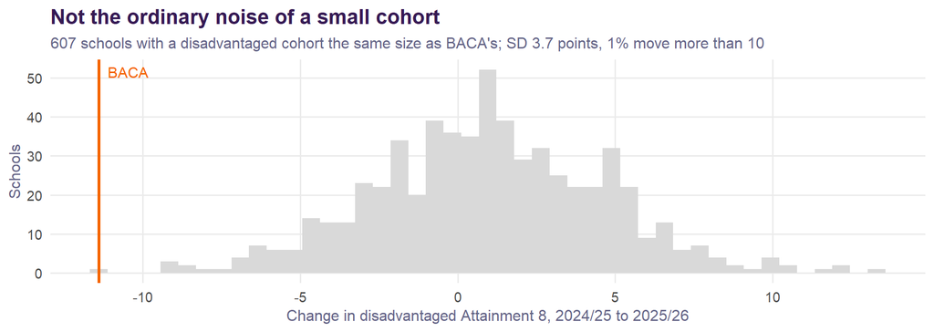

Year-on-year change in disadvantaged Attainment 8, schools with 60-79 disadvantaged pupils

Small cohorts do swing. But for schools with a disadvantaged cohort the size of BACA’s, the standard deviation of year-on-year change is 3.7 points and only 1% move by more than ten. BACA’s -11.4 sits at the 0.6th percentile of all 3,191 schools nationally. Whatever it is, it is not the usual noise.

**WarningDo not over-read this yet**

Three reasons for caution, all of them real:

1. **These are provisional figures.** February’s revisions will move them.
2. **One year.** The composition check above rules out the easy explanation, and the peer comparison rules out ordinary small-cohort noise — but a single cohort can still be unusual for reasons no published table shows. The thing to do is look again in February, and again in 2027.
3. **Attainment 8 is not value added.** The simulator’s third policy lever — “what if Longhill added value like BACA” — rests on a four-year value-added measure, not on one year of headline scores. A single year’s Attainment 8 cannot overturn it.

What this *does* justify is re-running the value-added measure with the new year in it, and seeing whether the gap that lever depends on is still there.

# 6 The value-added measure, re-run

Attainment 8 describes an intake. The measure the Brighton work leans on is **value added** — what a school adds once its intake is accounted for. In *How to Pull the Right Lever* it is the residual of the fitted model: observed Attainment 8 minus what the model expects, school by school and year by year, for **three pupil groups separately** — all pupils, disadvantaged, and non-disadvantaged. All three are carried into the new year here, because a comparison between them is most of the point.

The model behind it is the **imputed full specification** — nine predictors including prior attainment and three workforce terms — not the reduced core one. So the right way to add a fifth year is to **predict from the published models**, not to refit. Refitting moves all four published years; predicting leaves them untouched and puts 2025/26 on the same yardstick.

**NoteA back-transformation that used to be done two ways, now reconciled**

Checking this against the published league tables turned up an inconsistency in the project itself, since fixed.

The models are fitted on $\log(\text{ATT8SCR})$, so $\exp(\hat{y})$ is the conditional **median**. The expected score given a school’s intake is $\exp(\hat{y})\cdot\exp(\sigma^2/2)$. `safe_predict()` applied that correction, writing `residual_ATT8SCR_imputed` into the panel and from there into the simulator’s value-added scenario. The league tables and the observed-versus-predicted figure in the main report did not, and so printed residuals about **0.2 Attainment 8 points higher** for the same school and year.

Everything below uses the corrected form.

The four published years, recomputed against what the report prints

| Table | Group | School-years compared | Largest difference |
| --- | --- | --- | --- |
| tbl-league-all | all | 40 | 1.10 |
| tbl-league-dis | disadvantaged | 40 | 1.10 |

## 6.1 The league tables, extended

All pupils: value added by year, 2021/22 to 2025/26

| School | 2021-22 | 2022-23 | 2023-24 | 2024-25 | 2025-26 | Mean |
| --- | --- | --- | --- | --- | --- | --- |
| Varndean | 2.4 | 2.4 | 5.1 | -0.2 | 4.1 | 2.8 |
| Dorothy Stringer | 2.2 | 2.8 | 2.0 | 4.1 | 1.4 | 2.5 |
| King’s | 3.3 | 0.7 | 4.8 | -1.2 | -0.1 | 1.5 |
| Blatchington Mill | -1.8 | -1.2 | 1.7 | 1.7 | 2.4 | 0.6 |
| Portslade Aldridge | 3.7 | 0.4 | 2.2 | -1.9 | -2.3 | 0.4 |
| Hove Park School | 1.3 | 0.7 | 1.3 | -0.2 | -2.2 | 0.2 |
| BACA | 1.9 | 1.3 | 1.1 | 0.3 | -4.4 | 0.0 |
| Cardinal Newman Catholic | 1.1 | -2.5 | 1.0 | -2.2 | -2.2 | -1.0 |
| Longhill | -0.4 | -2.4 | -1.2 | -3.0 | -2.3 | -1.9 |
| Patcham | -3.0 | -3.1 | -4.6 | -3.6 | -2.1 | -3.3 |

Disadvantaged pupils: value added by year

| School | 2021-22 | 2022-23 | 2023-24 | 2024-25 | 2025-26 | Mean |
| --- | --- | --- | --- | --- | --- | --- |
| Blatchington Mill | -5.3 | 0.8 | 4.5 | 2.2 | 5.0 | 1.4 |
| Varndean | 1.9 | 2.9 | 3.7 | -3.1 | -0.3 | 1.0 |
| Cardinal Newman Catholic | 2.6 | -5.7 | 6.2 | 1.5 | -0.3 | 0.9 |
| King’s | 4.5 | 1.1 | 3.5 | -7.1 | 1.7 | 0.7 |
| BACA | 3.0 | -1.4 | 4.5 | 5.2 | -7.9 | 0.7 |
| Dorothy Stringer | 1.9 | 2.3 | -0.4 | 0.7 | -1.8 | 0.5 |
| Portslade Aldridge | 2.9 | -3.6 | 3.9 | -2.6 | -0.7 | 0.0 |
| Hove Park School | 2.7 | -2.7 | 1.8 | 0.5 | -4.6 | -0.5 |
| Longhill | -5.3 | -6.5 | 1.3 | -1.4 | 1.0 | -2.2 |
| Patcham | 3.8 | 1.2 | -11.9 | -4.2 | -4.2 | -3.1 |

Non-disadvantaged pupils: value added by year

| School | 2021-22 | 2022-23 | 2023-24 | 2024-25 | 2025-26 | Mean |
| --- | --- | --- | --- | --- | --- | --- |
| Varndean | 2.2 | 2.1 | 5.1 | 0.8 | 5.0 | 3.0 |
| Dorothy Stringer | 2.0 | 2.7 | 2.4 | 4.2 | 2.0 | 2.7 |
| King’s | 2.7 | 0.1 | 4.3 | 0.1 | -0.9 | 1.3 |
| BACA | 2.6 | 4.8 | -0.1 | -1.7 | 0.1 | 1.1 |
| Portslade Aldridge | 3.3 | 1.3 | 1.3 | -1.6 | -1.7 | 0.5 |
| Hove Park School | 0.4 | 1.8 | 0.9 | -0.3 | -0.4 | 0.5 |
| Blatchington Mill | -1.8 | -2.4 | 0.0 | 0.6 | 0.9 | -0.6 |
| Longhill | 2.7 | -1.4 | -2.7 | -3.2 | -4.0 | -1.7 |
| Cardinal Newman Catholic | 0.3 | -2.2 | -0.6 | -3.5 | -2.9 | -1.8 |
| Patcham | -4.5 | -4.7 | -2.9 | -3.4 | -1.3 | -3.3 |

## 6.2 The league tables as a picture

The tables above are hard to read as trajectories. These are the same numbers plotted, one panel per school, with a **three-year moving average** through them — centred where there are years either side, and trailing at the ends — to take out some of the year-to-year cohort noise.

A single year’s figure for one group in one school rests on a small number of children. The smoothed line is the better guide to direction; the points are what actually happened.

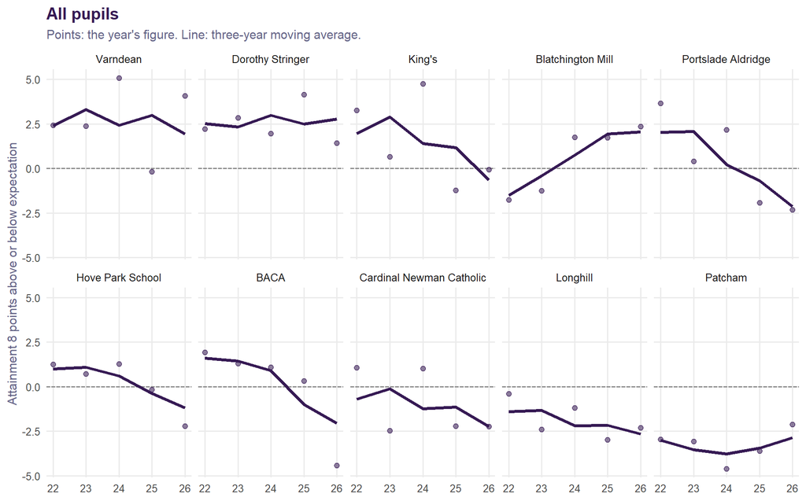

Figure 1: Value added by year, all pupils. Points are the published figures; the line is a three-year moving average. Schools ordered by five-year mean.

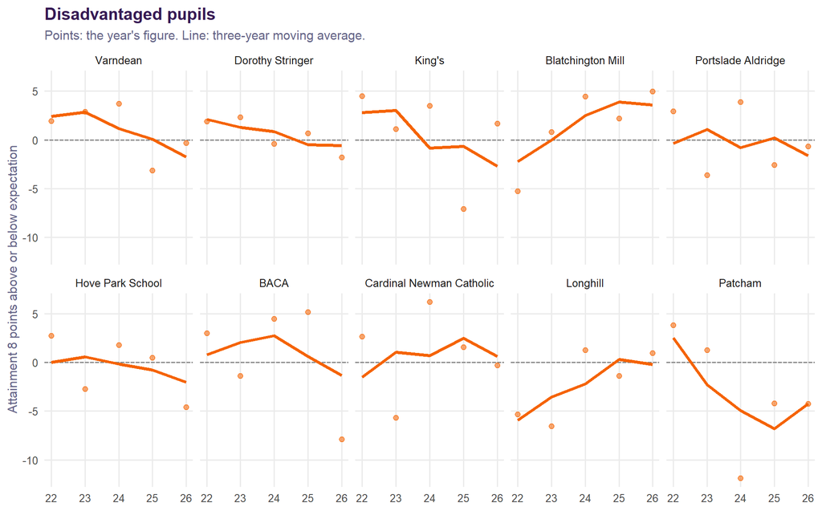

Figure 2: Value added by year, disadvantaged pupils. Small cohorts, so the smoothed line matters more here than anywhere else.

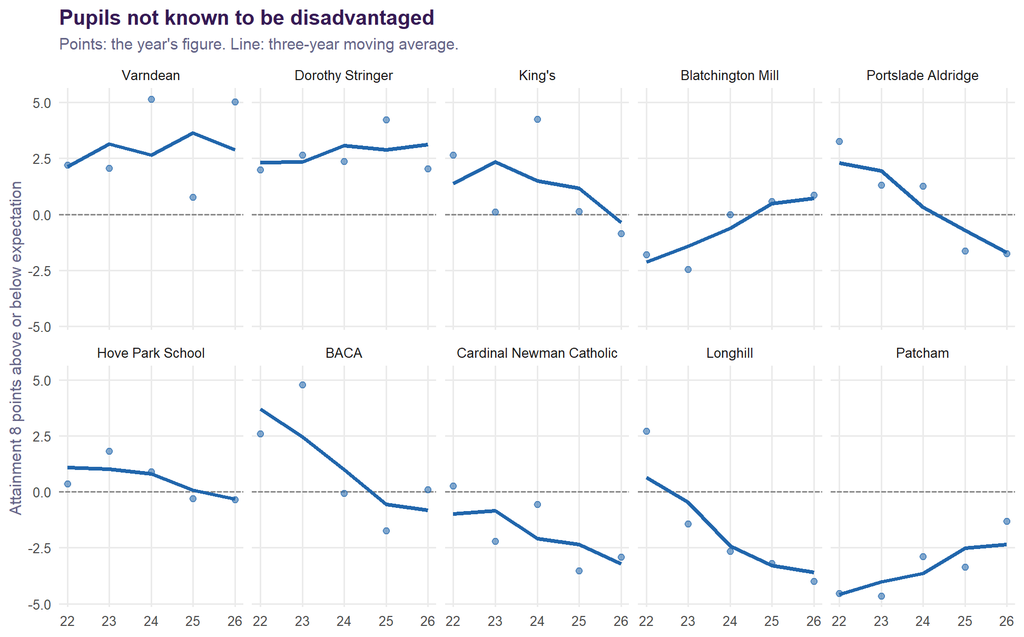

Figure 3: Value added by year, pupils not known to be disadvantaged

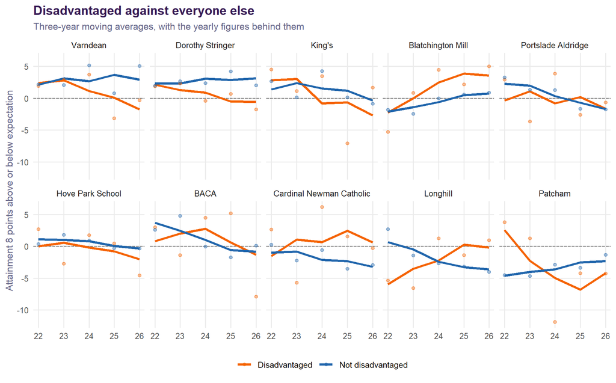

Figure 4: The two pupil groups on the same axes, smoothed. Where the lines diverge, a school is doing noticeably better for one group than the other.

**Longhill is the mirror image on the same measure**, climbing from -5.9 to -0.2 while its all-pupil line stays flat and negative. The all-pupil figure is hiding this.

## 6.3 BACA, by pupil group

The disadvantaged table is where the year lands hardest, and it is worth setting the raw scores beside the value added rather than reading either alone.

The two tables below pair them for each group of pupils. **A8** is the published Attainment 8 score — what the group actually achieved. **VA** is value added: that score minus what the model expects from the intake, so **zero means a group performed exactly as its intake predicted**, positive means better, negative worse. The groups are the DfE’s own: all pupils, pupils recorded as disadvantaged, and pupils *not known to be disadvantaged*, which is the rest of the year group.

BACA: Attainment 8 (A8) and value added (VA), by pupil group

| Year | A8: all pupils | VA: all pupils | A8: disadvantaged | VA: disadvantaged | A8: not disadvantaged | VA: not disadvantaged |
| --- | --- | --- | --- | --- | --- | --- |
| 2021-22 | 37.4 | 1.9 | 31.0 | 3.0 | 43.1 | 2.6 |
| 2022-23 | 36.2 | 1.3 | 25.9 | -1.4 | 44.6 | 4.8 |
| 2023-24 | 37.3 | 1.1 | 32.9 | 4.5 | 41.1 | -0.1 |
| 2024-25 | 36.1 | 0.3 | 33.2 | 5.2 | 39.3 | -1.7 |
| 2025-26 | 33.2 | -4.4 | 21.9 | -7.9 | 42.7 | 0.1 |

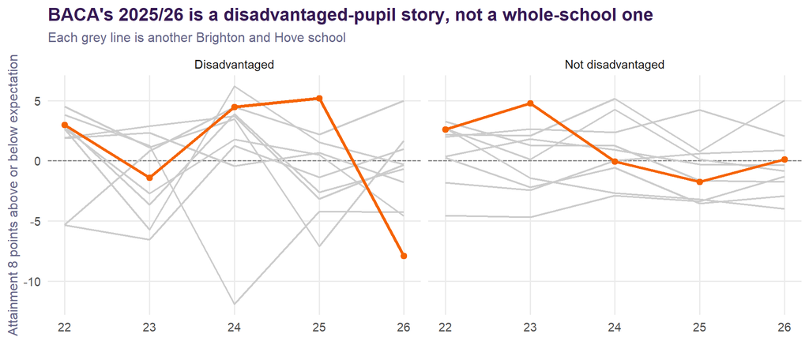

BACA: value added by pupil group, against the rest of the city

Read across the groups, the year separates cleanly.

**BACA’s non-disadvantaged pupils had a good year.** Attainment 8 39.3 to 42.7, value added -1.7 to +0.1 — back above expectation.

**Its disadvantaged pupils did not.** Attainment 8 33.2 to 21.9, and value added **+5.2 to -7.9** — a swing of 13.1 points in one year.

And the four years before it ran the other way. On the four published years BACA was **the best school in the city** for disadvantaged value added — mean +2.8, and improving: +4.5 then +5.2 in the two most recent. Whatever happened in 2025/26 reversed a school that was, on this measure, doing the thing the whole *Pulling the Right Lever* argument says matters most.

**WarningThis is one provisional year, and it is a small group**

BACA’s disadvantaged cohort is 46% of 147 pupils. The composition check earlier rules out an intake effect and the national peer comparison rules out ordinary noise, but a single cohort can still be unusual for reasons no published table carries — and February’s revisions have not landed. Treat it as a flag to investigate, not a finding.

**NoteContext from the school**

Conversations with the school’s leadership have provided important context for the size of the swing. The underlying figures are not mine to publish and are not reproduced here, but two of the headline differences bear directly on the published data above, and the account is incomplete without them.

**A substantial part of the cohort did not sit exams at all** — more than one pupil in ten. Setting those pupils aside lifts the school’s results materially above the published figure and much closer to the year before. That is the same effect §7 reaches from the published entry rate, and it confirms the published rate *understates* the problem: a pupil can be entered and still not sit the paper, and only the entry shows up in the data.

**Attainment splits by attendance far more sharply than it splits by school.** Pupils attending 95% or more of the year scored around 49 in Attainment 8. Pupils attending between 80% and 90% scored roughly 26 points lower. For scale, the published distance between the highest- and lowest-scoring secondary schools in the whole of Brighton and Hove is 23 points — **smaller than the gap between two groups of children in the same building**.

And the comparison that follows from it: at around 49 points, BACA’s regular attenders would sit **6th of the ten schools** on the city’s published table, ahead of 4 of them — against a published school figure of 33.2 that places it last.

Neither figure is verifiable by a reader and neither is offered as evidence. They are the reason the published analysis is framed the way it is: a school is not one number, and the headline is doing a poor job of describing the thing parents believe they are reading it for.

## 6.4 Longhill, for contrast

Longhill: Attainment 8 (A8) and value added (VA), by pupil group

| Year | A8: all pupils | VA: all pupils | A8: disadvantaged | VA: disadvantaged | A8: not disadvantaged | VA: not disadvantaged |
| --- | --- | --- | --- | --- | --- | --- |
| 2021-22 | 44.1 | -0.4 | 29.3 | -5.3 | 51.7 | 2.7 |
| 2022-23 | 35.8 | -2.4 | 22.5 | -6.5 | 41.1 | -1.4 |
| 2023-24 | 36.1 | -1.2 | 29.1 | 1.3 | 39.3 | -2.7 |
| 2024-25 | 32.9 | -3.0 | 25.5 | -1.4 | 37.8 | -3.2 |
| 2025-26 | 36.3 | -2.3 | 30.4 | 1.0 | 39.3 | -4.0 |

So on the measure the Brighton argument cares about most — what a school adds for disadvantaged children — **Longhill improved and BACA fell**. That is a stronger statement than the headline scores support on their own, and close to the reverse of what the raw Attainment 8 comparison first suggested.

One qualification, which §7 sets out. The value added here is built on Attainment 8 as published, a mean over every pupil on roll. Longhill’s entry rate rose sharply across these two years and BACA’s fell, so part of both movements is a change in who was counted rather than in what anyone scored. Measured on entered pupils only, Longhill is close to flat over three years and BACA’s decline is steadier and smaller than the headline. The direction of both survives; the size does not.

## 6.5 The prior attainment the model wants, and cannot have

The model carries `ks2_c` — the mean Key Stage 2 scaled score of the school’s Year 11 intake, centred at 100. It is the term that stops a school being penalised for admitting children who arrived behind. For the two most recent years it does not exist.

Schools with a Key Stage 2 intake score in the performance tables

| KS4 year | Sat KS2 in | Schools with a score |
| --- | --- | --- |
| 2021/22 | 2016/17 | 5,617 |
| 2022/23 | 2017/18 | 5,684 |
| 2023/24 | 2018/19 | 5,743 |
| 2024/25 | 2019/20 | 251 |
| 2025/26 | 2020/21 | 0 |

The 2019/20 and 2020/21 Key Stage 2 assessments were cancelled. **The data does not exist and will not appear later** — this is not a sourcing problem that a better download would fix. It is the same cancellation that removed Progress 8 from these two years, and DfE have confirmed no replacement measure for either. The EES institution-level file carries a prior-attainment breakdown for 2023/24 only, for the same reason.

So `ks2_c` for 2025/26 is **carried forward twice** — from 2023/24 to 2024/25 by the existing pipeline, and from 2024/25 to 2025/26 here. That is a real assumption, and the question is how much weight it bears.

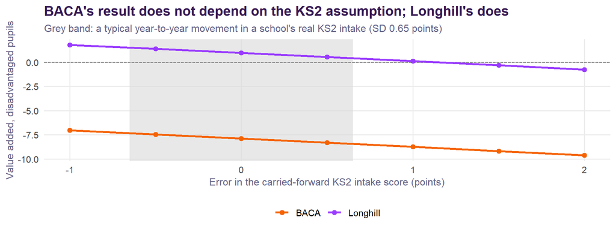

How BACA’s 2025/26 value added moves if the carried-forward KS2 figure is wrong

Two different answers, and the contrast is the useful part.

**BACA’s result does not rest on it.** For the carried-forward KS2 figure to explain away a residual of -7.9, the cohort’s actual KS2 mean would have to have been **-10.8 points** below the carried-forward value — about 17 times a typical year’s movement in a school’s intake, and far outside anything observed. A plausible error of ±0.65 moves the figure by about 0.6 of a point.

**Longhill’s does.** Its +1.0 for disadvantaged pupils is the first positive figure it has recorded on that measure since 2023/24, but it sits close enough to zero that a KS2 error of two points would erase it. Treat the direction as suggestive and the number as soft.

**NoteWhat would actually fix this**

Nothing, for these two cohorts. The first KS4 year with a real Key Stage 2 baseline again is **2026/27** — children who sat KS2 in 2021/22, the first normal sitting after the cancellations. Until then every value-added figure for 2024/25 and 2025/26 rests on a carried-forward intake score, in this analysis and in anyone else’s.

## 6.6 What it does to the third policy lever

The simulator’s third lever asks what happens if Longhill’s value added doubled, “to roughly where BACA already is with a comparably disadvantaged intake”. That framing depends on a gap between the two schools.

The four-year school means reproduce what the simulator ships to within 0.15.

|  | Longhill | BACA | Gap |
| --- | --- | --- | --- |
| Four years (as shipped) | -1.75 | +1.16 | +2.91 |
| **Five years** | **-1.86** | **+0.04** | **+1.90** |

The gap is **34% smaller**, and BACA’s all-pupil value added falls from +1.16 to +0.04 — from clearly beating what its intake predicts to sitting almost exactly on it.

## 6.7 And to the simulator’s attractiveness term

Attractiveness multipliers under the ‘families read value added’ scenario

| School | As published | With 2025/26 | Change |
| --- | --- | --- | --- |
| BACA | 2.630 | 2.145 | -0.485 |
| Portslade Aldridge | 1.364 | 1.231 | -0.132 |
| Hove Park | 1.330 | 1.225 | -0.105 |
| Longhill | 1.241 | 1.262 | 0.022 |
| Dorothy Stringer | 1.236 | 1.256 | 0.021 |
| Varndean | 1.126 | 1.334 | 0.208 |
| King’s | 0.773 | 0.753 | -0.020 |
| Blatchington Mill | 0.761 | 0.903 | 0.142 |
| Cardinal Newman Catholic | 0.541 | 0.517 | -0.023 |
| Patcham | 0.382 | 0.415 | 0.033 |

**ImportantWhat this means for the simulator, and what it does not**

**The scenario still works.** “What if families read value added” remains a real lever, and it still redistributes demand. But the *shape* of that redistribution has changed, and the shipped multipliers are a year out of date.

**The third lever needs rewording, not retiring.** “Double Longhill’s value added” is still coherent. “To roughly where BACA already is” is a much weaker claim on five years than on four — and if the lever is meant to be about disadvantaged pupils specifically, the comparison it should make is now the other way round.

**One provisional year is doing all the work.** Before rebuilding attractiveness on this, wait for February.

# 7 Who sat the exam, and who was in the room

Everything above compares Attainment 8 school by school and year by year. That comparison has an assumption buried in it: that the schools are being measured on the same pupils. They are not, and the published data says so.

Attainment 8 is a mean over **every pupil on roll at the end of Key Stage 4**, whether or not they were entered for anything. A pupil entered for nothing scores zero and stays in the denominator. So a school’s headline number moves when its entry rate moves, without a single child doing better or worse.

## 7.1 How unusual BACA’s entry rate is

Brighton Aldridge: pupils on roll, pupils entered for English and maths, and Attainment 8 measured both ways

| Year | On roll | Entered | Entered % | A8 per pupil on roll | A8 per pupil entered |
| --- | --- | --- | --- | --- | --- |
| 23/24 | 117 | 114 | 97.4 | 37.3 | 38.3 |
| 24/25 | 116 | 112 | 96.6 | 36.2 | 37.5 |
| 25/26 | 147 | 138 | 93.9 | 33.2 | 35.4 |

In 2025/26 BACA entered **93.9%** of its cohort for English and maths. **105 of the 3,278 state-funded mainstream schools in England entered a smaller share** — so it sits near the bottom of the country on this, not the top. The national median is 98.5%.

That is about 9 pupils of 147 not entered, each scoring zero in a mean taken over all of them.

**ImportantEntered is not the same as sat**

The published figure counts pupils **entered**. A school can enter a pupil who then does not sit the paper, and that pupil also scores zero. Nothing in the published data separates the two, so the entry rate is a **floor** on how many children contributed a zero, not a measure of it.

That matters most in schools where attendance is weakest, which is where entry rates are lowest. BACA is at 39% persistent absence.

## 7.2 The same measure, like for like

Brighton and Hove, three years, Attainment 8 per pupil on roll and per pupil entered

| School | 25/26 roll | 25/26 entered | 24/25 roll | 24/25 entered | 23/24 roll | 23/24 entered |
| --- | --- | --- | --- | --- | --- | --- |
| BACA | 33.2 | 35.4 | 36.2 | 37.5 | 37.3 | 38.3 |
| Blatchington Mill | 52.5 | 53.3 | 51.0 | 52.7 | 52.4 | 54.6 |
| Cardinal Newman Catholic | 50.9 | 51.8 | 50.4 | 51.8 | 54.4 | 55.0 |
| Dorothy Stringer | 50.5 | 51.3 | 53.3 | 54.4 | 49.8 | 51.1 |
| Hove Park School | 42.0 | 43.8 | 41.1 | 42.8 | 43.3 | 46.0 |
| King’s | 56.5 | 57.1 | 53.7 | 55.4 | 60.0 | 60.4 |
| Longhill | 36.3 | 37.0 | 32.9 | 36.0 | 36.1 | 37.7 |
| Patcham | 46.7 | 49.1 | 45.5 | 48.9 | 44.0 | 46.1 |
| Portslade Aldridge | 44.1 | 45.3 | 42.7 | 44.8 | 46.6 | 46.8 |
| Varndean | 54.7 | 56.4 | 48.8 | 51.0 | 53.5 | 54.4 |

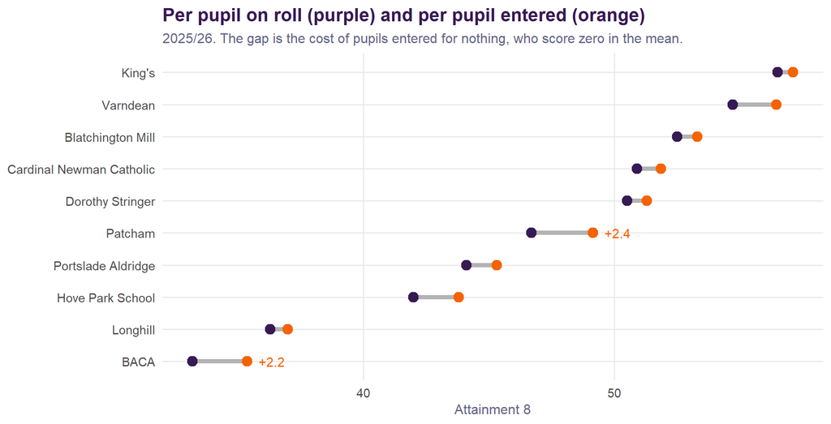

Attainment 8 measured two ways, Brighton and Hove. The distance between the points is what entry rates are doing to the headline number.

Two readings in this report change once the measure is held constant.

**BACA’s fall is smaller than the headline, and real.** Per pupil on roll it fell -3.0; per pupil entered, -2.1. So entry accounts for about 29% of it and the rest is a genuine fall among the pupils who were entered. Its entered figure has declined in each of the three published years — 38.3, 37.5, 35.4 — so this is a trend, not one bad summer.

**Longhill’s rise is mostly its entry rate recovering.** Per pupil on roll it rose +3.4, which is the figure §5.1 reports. But its entry rate went 91.4% to 98.1%, and per pupil entered the rise is only +1.0. Across three years its entered figure runs 37.7, 36.0, 37.0 — close to flat.

## 7.3 Three years, England and Brighton

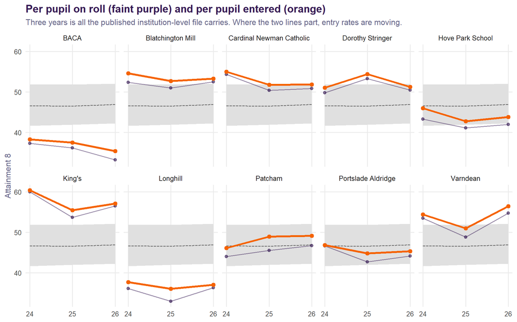

Attainment 8 measured per pupil on roll and per pupil entered, 2023/24 to 2025/26. Grey band: the middle half of schools in England on the entered measure.

Only three years exist at school level — the institution-level file starts in 2023/24 — so this cannot be run back across the five years §9 uses.

## 7.4 Value added on the pupils who sat

The value added in §6 is built on Attainment 8 as published, which means a school is credited or penalised for pupils who were never entered. The measure can be rebuilt on the entered figure instead. Same specification, same three years, same schools: only the outcome changes.

The entered outcome is the **better behaved of the two**: residual standard deviation 0.0782 against 0.1001 on the log scale. Removing pupils who were never entered removes noise that has nothing to do with teaching.

The two rankings are close — the residuals correlate at 0.95 — but where they differ they differ for one reason. The shift between them correlates **+0.84** with the share of pupils not entered.

Brighton and Hove: value added on pupils on roll and on pupils entered, same model, same years

| School | Year | Entry % | VA, on roll | VA, entered |
| --- | --- | --- | --- | --- |
| BACA | 2023-24 | 97.4 | -0.25 | -1.03 |
| BACA | 2024-25 | 96.6 | -0.16 | -0.68 |
| BACA | 2025-26 | 93.9 | -5.00 | -4.70 |
| Blatchington Mill | 2023-24 | 95.9 | 3.22 | 3.57 |
| Blatchington Mill | 2024-25 | 96.6 | 4.57 | 4.38 |
| Blatchington Mill | 2025-26 | 98.5 | 5.97 | 4.80 |
| Cardinal Newman Catholic | 2023-24 | 98.9 | 1.93 | 0.66 |
| Cardinal Newman Catholic | 2024-25 | 97.3 | 0.95 | 0.40 |
| Cardinal Newman Catholic | 2025-26 | 98.1 | 1.86 | 0.89 |
| Dorothy Stringer | 2023-24 | 97.5 | 3.49 | 3.07 |
| Dorothy Stringer | 2024-25 | 97.9 | 5.15 | 4.43 |
| Dorothy Stringer | 2025-26 | 98.5 | 4.02 | 2.91 |
| Hove Park School | 2023-24 | 94.1 | 0.48 | 1.28 |
| Hove Park School | 2024-25 | 96.0 | -0.05 | -0.36 |
| Hove Park School | 2025-26 | 96.0 | -2.25 | -2.32 |
| King’s | 2023-24 | 99.4 | 4.57 | 3.36 |
| King’s | 2024-25 | 96.9 | 0.78 | 0.97 |
| King’s | 2025-26 | 98.9 | 2.50 | 1.44 |
| Longhill | 2023-24 | 95.9 | -2.59 | -2.83 |
| Longhill | 2024-25 | 91.4 | -3.11 | -1.98 |
| Longhill | 2025-26 | 98.1 | -2.89 | -4.12 |
| Patcham | 2023-24 | 95.5 | -4.15 | -3.65 |
| Patcham | 2024-25 | 93.1 | -3.38 | -1.66 |
| Patcham | 2025-26 | 95.1 | -0.91 | -0.12 |
| Portslade Aldridge | 2023-24 | 99.5 | 2.45 | 0.99 |
| Portslade Aldridge | 2024-25 | 95.3 | -0.93 | -0.56 |
| Portslade Aldridge | 2025-26 | 97.4 | -0.51 | -0.90 |
| Varndean | 2023-24 | 98.3 | 6.19 | 5.43 |
| Varndean | 2024-25 | 95.7 | 1.58 | 1.95 |
| Varndean | 2025-26 | 96.9 | 5.76 | 5.73 |

Two schools move enough to change what you would say about them.

**BACA’s 2025/26 survives the correction.** Value added -5.0 on roll, -4.7 on entered, against roughly -0.7 the year before. Entry explains part of the headline fall and nothing like all of it.

**Longhill reverses.** On roll its value added is flat across the three years — -2.6, -3.1, -2.9. On the pupils who sat it runs -2.8, -2.0, -4.1, making 2025/26 its **worst** of the three rather than a recovery. Its entry rate went 91.4% to 98.1% across those years, so the pupils it added back to the count were ones it had previously not entered.

**Warning**

This is a different model from §6 — three years rather than five, the core specification, fitted separately for each outcome. The levels are not comparable with the league tables there; only the comparison between the two columns is.

## 7.5 What a low entry rate is telling you

A school entering fewer of its pupils is not usually making an administrative choice. The published data lets this be checked directly: entry rates from the Key Stage 4 file, special educational needs from the school-level SEN release, absence from the absence release.

England 2025/26, schools grouped by the share of their cohort not entered for English and maths

| Not entered | Schools | Disadvantaged % | EHC plan % | SEN support % | Persistently absent % | Attainment 8 |
| --- | --- | --- | --- | --- | --- | --- |
| under 1% | 1162 | 26.0 | 3.0 | 12.7 | 17.9 | 52.5 |
| 1-2% | 902 | 29.6 | 3.6 | 14.7 | 21.8 | 46.7 |
| 2-5% | 1030 | 32.9 | 4.3 | 16.2 | 25.4 | 43.2 |
| 5-10% | 149 | 42.7 | 5.4 | 18.0 | 31.3 | 38.1 |
| 10% and over | 15 | 43.8 | 6.5 | 20.6 | 32.2 | 30.4 |

Every column rises together. Schools that enter nearly everyone have a quarter of their pupils disadvantaged and one in thirty-three on an education, health and care plan. Schools leaving more than one pupil in ten unentered have 44% disadvantaged, twice the rate of plans, and a third of the school persistently absent.

What predicts the share of a cohort left unentered

| Term | Estimate | Std. error | p |
| --- | --- | --- | --- |
| Disadvantaged % | 0.0012 | 0.0031 | 0.69 |
| Persistently absent % | 0.0927 | 0.0067 | <1e-04 |
| EHC plan % | 0.1427 | 0.0205 | <1e-04 |
| SEN support % | 0.0098 | 0.0083 | 0.24 |

Put together, **absence and education, health and care plans are what carry it**; the disadvantage and SEN-support terms stop mattering once those two are in. The model explains 13% of the variation, so most of what decides a school’s entry rate is still local to that school — but the part that is predictable is predictable from statutory need and from children not being in the building.

A pupil who is not entered is almost never a pupil who could have been entered and was not bothered with. They are disproportionately children with an education, health and care plan, and children who have not been in school enough to sit anything. **Attainment 8 counts them as a zero and says nothing about why.**

The extreme case in England makes the point better than any argument. One school — Europa School UK, in Oxfordshire — enters 1.7% of its cohort for English and maths and scores -55.8 on value added as conventionally measured. On the pupils who actually sat, it scores +20.6. Nothing about the teaching changed between those two numbers.

# 8 What this says about reading a school by its headline

The entry gap is a small correction for most schools and a large one for a few. What moves Attainment 8 far more than either is something no league table puts next to it.

Attainment 8 by how much of the school is persistently absent, England, 2025/26

| Persistently absent | Schools | Attainment 8 | Per pupil entered | Disadvantaged % |
| --- | --- | --- | --- | --- |
| under 10% | 207 | 67.3 | 67.9 | 15.0 |
| 10-20% | 1066 | 51.9 | 52.5 | 24.0 |
| 20-30% | 1557 | 44.0 | 45.0 | 32.2 |
| 30-40% | 375 | 38.2 | 39.5 | 43.8 |
| 40% and over | 53 | 33.1 | 34.6 | 48.5 |

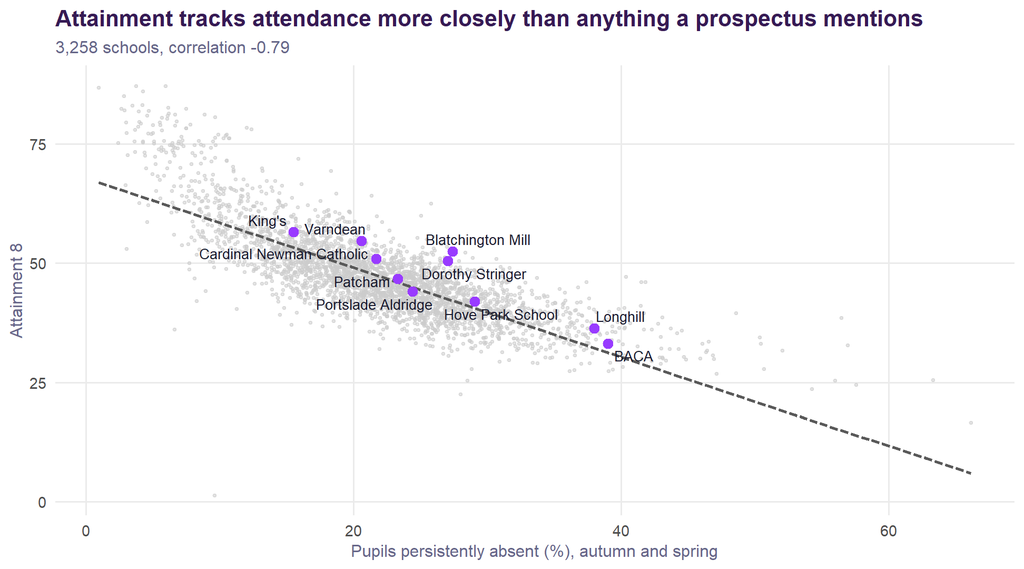

Every state-funded mainstream secondary in England, 2025/26. Brighton and Hove’s ten are marked.

Across 3,258 schools the correlation between Attainment 8 and the share of pupils persistently absent is **-0.79**. Schools where fewer than one pupil in ten is persistently absent average 67.3. Schools where more than two in five are average 33.1. That is a spread of **34 Attainment 8 points** — far larger than anything the value-added tables in §6 separate schools by.

A family choosing on the headline score is, to a first approximation, choosing on how often other people’s children come to school. The number is real, and it is mostly not about teaching.

This is the argument *How to Pull the Right Lever* makes nationally, and it is why that report controls for absence before it ranks anything. The 2025/26 data does not soften it. What the new year adds is that **entry rates belong in the same sentence**: two published numbers, both ignored in every league table a parent will ever see, between them explain more of the difference between Brighton’s schools than any plausible difference in how well they teach.

# 9 Five years of Brighton and Hove, against England

Everything above is about one year. This is the series the new year joins: the city’s ten state-funded secondary schools from 2021/22 to 2025/26, on both measures, with England drawn behind them.

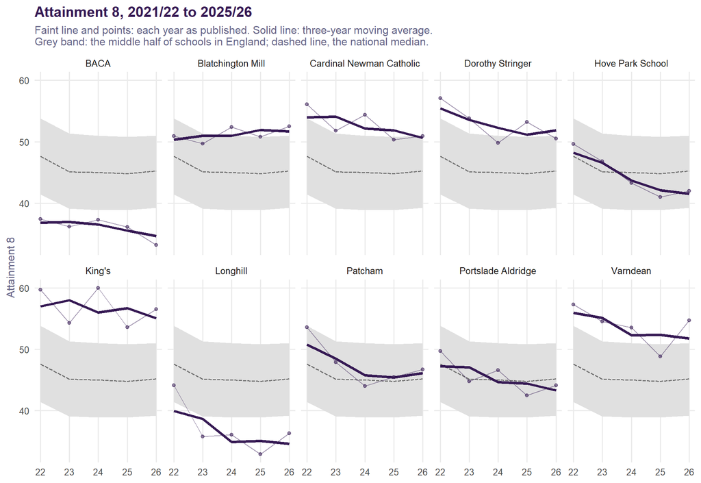

Attainment 8, Brighton and Hove schools against the national distribution

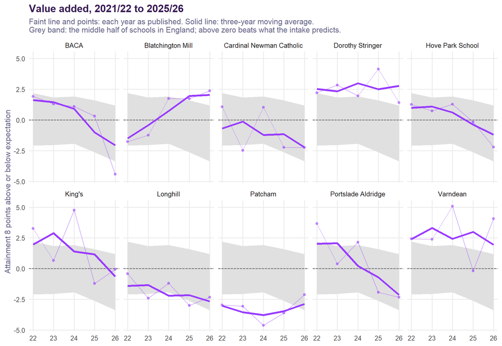

Value added, Brighton and Hove schools. Zero is performing exactly as the intake predicts.

Read side by side, the two charts say different things about the same city.

On **Attainment 8** the schools are spread across the national distribution, and the ordering barely changes from year to year — which is the point *How to Pull the Right Lever* makes about the headline measure: it mostly restates who walks through the door.

On **value added** the city is tighter and the movement is larger. A school can sit in the bottom quarter of England on Attainment 8 and still be adding what its intake predicts.

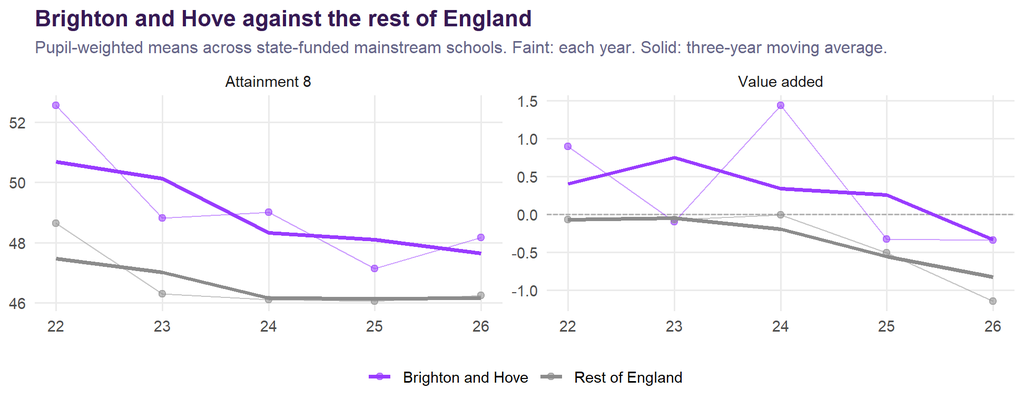

The city against England, both measures, pupil-weighted

Pupil-weighted, the city’s Attainment 8 ran 52.6 in 2021/22 and 48.2 in 2025/26, against 48.6 and 46.3 for the rest of England. On value added the city sat at +0.90 and -0.34.

Brighton and Hove schools, five years, both measures

| School | 21/22 A8 | 21/22 VA | 22/23 A8 | 22/23 VA | 23/24 A8 | 23/24 VA | 24/25 A8 | 24/25 VA | 25/26 A8 | 25/26 VA |
| --- | --- | --- | --- | --- | --- | --- | --- | --- | --- | --- |
| BACA | 37.4 | 1.9 | 36.2 | 1.3 | 37.3 | 1.1 | 36.1 | 0.3 | 33.2 | -4.4 |
| Blatchington Mill | 50.9 | -1.8 | 49.7 | -1.2 | 52.4 | 1.7 | 50.8 | 1.7 | 52.5 | 2.4 |
| Cardinal Newman Catholic | 56.1 | 1.1 | 51.8 | -2.5 | 54.4 | 1.0 | 50.3 | -2.2 | 50.9 | -2.2 |
| Dorothy Stringer | 57.1 | 2.2 | 53.8 | 2.8 | 49.8 | 2.0 | 53.2 | 4.1 | 50.5 | 1.4 |
| Hove Park School | 49.6 | 1.3 | 46.8 | 0.7 | 43.3 | 1.3 | 41.0 | -0.2 | 42.0 | -2.2 |
| King’s | 59.7 | 3.3 | 54.3 | 0.7 | 60.0 | 4.8 | 53.6 | -1.2 | 56.5 | -0.1 |
| Longhill | 44.1 | -0.4 | 35.8 | -2.4 | 36.1 | -1.2 | 32.9 | -3.0 | 36.3 | -2.3 |
| Patcham | 53.6 | -3.0 | 47.9 | -3.1 | 44.0 | -4.6 | 45.5 | -3.6 | 46.7 | -2.1 |
| Portslade Aldridge | 49.7 | 3.7 | 44.8 | 0.4 | 46.6 | 2.2 | 42.5 | -1.9 | 44.1 | -2.3 |
| Varndean | 57.3 | 2.4 | 54.5 | 2.4 | 53.5 | 5.1 | 48.8 | -0.2 | 54.7 | 4.1 |

# 10 Where this leaves things

**Settled.** The new year can be added, the new source agrees with the old one, and the central Lever finding is unchanged by both the extra year and the change of absence basis.

**Worth watching, not acting on.** On the measure the argument cares about most — what a school adds for disadvantaged children — Longhill improved and BACA fell, and BACA’s fall reverses four years in which it was the best school in the city on that measure. Both sit on one provisional year, and §7 shows that part of both movements is entry rates rather than attainment.

**The finding worth taking further.** Attainment 8 is a mean over every pupil on roll, so a school’s headline moves when its entry rate moves and when its attendance moves, without anyone teaching better or worse. Across England the correlation between Attainment 8 and the share of pupils persistently absent is −0.79, and the spread from the least absent schools to the most is 34 points — larger than anything the value-added tables here separate schools by. Entry rates and attendance are both published, both ignored by every league table a family will see, and between them they explain more of the difference between Brighton’s schools than any plausible difference in teaching. That belongs in the main report, not in an addendum, and it is the strongest argument in this document for the case *How to Pull the Right Lever* already makes.

**Deliberately not done.** Three things this addendum stops short of, each for the same reason:

- *The main report is not revised.* *How to Pull the Right Lever* still stands on four years. Its league tables, its coefficients and its conclusions are untouched.
- *The simulator is not rebuilt.* The shipped attractiveness multipliers are a year out of date, and the third policy lever’s “roughly where BACA already is” no longer holds as stated — but rebuilding on a provisional year would be the wrong move.
- *The published panel is not replaced.* `data/panel_data.rds` is untouched, so every published figure still reproduces from exactly the files it was built on. The five-year panel is written separately to `data/panel_data_5yr.rds`.

**What would change that.** February 2027, when 2025/26 is revised and the full-year absence series catches up. At that point three decisions become live: whether to fold this year into the main report, whether to rebuild the simulator’s attractiveness on five years, and whether to adopt the **revised** 2024/25 figures EES now carries in place of the provisional ones the published analysis used — a difference of about 0.12 Attainment 8 points.

**NoteSources**

All figures from Department for Education statistics, Open Government Licence v3.0.

- *Key stage 4 performance, Academic year 2025/26* — Key stage 4 institution level: Performance. Published 15 October 2026. Provisional.
- *Pupil absence in schools in England, Autumn and spring term 2025/26* — Absence, school level, autumn and spring terms combined. Published 15 October 2026.
- *Schools, pupils and their characteristics, Academic year 2025/26* — School level underlying data, January 2026 census.